# *ChemmineR*

Fuentes de datos Biomédicas y Web semántica Grado de Ingeniería de la Salud

Paula Rastrilla** *email*.

22 diciembre, 2021

# 1. Introducción, objetivos y justificación

#### **Introducción**

A lo largo de este seminario, se pretende conocer las funciones del paquete *ChemmineR* como parte de **BiocManager**.

#### **Objetivos**

1. Conocer el funcionamiento del paquete ChemmineR y los datos que permite procesar.
2. Aplicar a un conjunto de datos molecular las funciones del paquete dplyr.

# 2. Instalación de paquetes y carga de datos

## 2.1 Instalación de paquetes

```r
# Carga de las librerías necesarias:
library(readr)
library(tidyverse)
library(dplyr)
library(DT)
library(BiocManager)
BiocManager::install("ChemmineR", force = TRUE)
library(ChemmineR)
```

## 2.2 Carga de datos

```r
Datos_ChemmineR <- read.SDFset("INPUT/DATA/sdfsample.sdf")

PequeñasMoléculas <- read.delim("INPUT/DATA/SmallMolecules.csv", sep = ";")
```

El primer archivo es de tipo SDF, utilizados para almacenar bases de datos en un formato estructurado. Es una extensión de archivo estándar que no está asociada con ningún programa ni base de datos. Por tanto, estos archivos tienen un amplio espectro de programas en los que pueden ser exportados, permitiendo trabajar con ellos sin problemas de formato.

### Conversión de datos

- *smiles2sdf*: convierte un archivo SMILES a un objeto SDF
- *sdf2smiles*: convierte un objeto SDF o un archivo SMILES
- *convertFormat*: convierte cadenas entre dos formatos distintos
- *convertFormatFile*: convierte archivos entre dos formatos distintos.

# 3. Aplicaciones prácticas

A continuación se muestra un ejemplo con el set de datos de 100 moléculas, a modo de ejemplo.

```r
data(sdfsample)
sdfset <- sdfsample
sdfset
```

```
## An instance of "SDFset" with 100 molecules
```

```r
summary(sdfset)
```

```
## Length  Class   Mode
##    100 SDFset     S4
```

Se seleccionan las primeras 4 moléculas de la instancia.  
Se selecciona 1 molécula a mostrar, utilizando los dobles corchetes.

```r
sdfset[1:4]
```

```
## An instance of "SDFset" with 4 molecules
```

```r
sdfset[[1]]
```

```
## An instance of "SDF"
##
## <<header>>
##                             Molecule_Name
##                                  "650001"
##                                    Source
##                  "  -OEChem-07071010512D"
##                                   Comment
##                                        ""
##                               Counts_Line
## " 61 64  0     0  0  0  0  0  0999 V2000"
##
## <<atomblock>>
##           C1      C2  C3  C5  C6  C7  C8  C9 C10 C11 C12 C13 C14 C15 C16
## O_1   7.0468  0.0839   0   0   0   0   0   0   0   0   0   0   0   0   0
## O_2  12.2708  1.0492   0   0   0   0   0   0   0   0   0   0   0   0   0
## ...      ...     ... ... ... ... ... ... ... ... ... ... ... ... ... ...
## H_60  1.8411 -1.5985   0   0   0   0   0   0   0   0   0   0   0   0   0
## H_61  2.6597 -1.2843   0   0   0   0   0   0   0   0   0   0   0   0   0
##
## <<bondblock>>
##      C1  C2  C3  C4  C5  C6  C7
## 1     1  16   2   0   0   0   0
## 2     2  23   1   0   0   0   0
## ... ... ... ... ... ... ... ...
## 63   33  60   1   0   0   0   0
## 64   33  61   1   0   0   0   0
##
## <<datablock>> (33 data items)
##           PUBCHEM_COMPOUND_CID PUBCHEM_COMPOUND_CANONICALIZED
##                       "650001"                            "1"
##      PUBCHEM_CACTVS_COMPLEXITY  PUBCHEM_CACTVS_HBOND_ACCEPTOR
##                          "700"                            "7"
##
##                          "..."
```

La instancia de sdf se subdivide en un *cabecero* con el nombre de la molécula, un *bloque de átomos* que muestra qué elementos componen la molécula, un *bloque de uniones* que muestra los tipos de enlaces entre los átomos y un *bloque de datos* con los identificadores moleculares que se usan para localizarla dentro de los buscadores.

Con el comando view se puede ver la información que contiene el conjunto seleccionado entre corchetes.

```r
view(sdfset[1:4])
```

```
## $CMP1
## An instance of "SDF"
##
## <<header>>
##                             Molecule_Name
##                                  "650001"
##                                    Source
##                  "  -OEChem-07071010512D"
##                                   Comment
##                                        ""
##                               Counts_Line
## " 61 64  0     0  0  0  0  0  0999 V2000"
##
## <<atomblock>>
##           C1      C2  C3  C5  C6  C7  C8  C9 C10 C11 C12 C13 C14 C15 C16
## O_1   7.0468  0.0839   0   0   0   0   0   0   0   0   0   0   0   0   0
## O_2  12.2708  1.0492   0   0   0   0   0   0   0   0   0   0   0   0   0
## ...      ...     ... ... ... ... ... ... ... ... ... ... ... ... ... ...
## H_60  1.8411 -1.5985   0   0   0   0   0   0   0   0   0   0   0   0   0
## H_61  2.6597 -1.2843   0   0   0   0   0   0   0   0   0   0   0   0   0
##
## <<bondblock>>
##      C1  C2  C3  C4  C5  C6  C7
## 1     1  16   2   0   0   0   0
## 2     2  23   1   0   0   0   0
## ... ... ... ... ... ... ... ...
## 63   33  60   1   0   0   0   0
## 64   33  61   1   0   0   0   0
##
## <<datablock>> (33 data items)
##           PUBCHEM_COMPOUND_CID PUBCHEM_COMPOUND_CANONICALIZED
##                       "650001"                            "1"
##      PUBCHEM_CACTVS_COMPLEXITY  PUBCHEM_CACTVS_HBOND_ACCEPTOR
##                          "700"                            "7"
##
##                          "..."
##
## $CMP2
## An instance of "SDF"
##
```

[output cut: 92 more lines]

```
## <<bondblock>>
##      C1  C2  C3  C4  C5  C6  C7
## 1     1  15   1   0   0   0   0
## 2     1  22   1   0   0   0   0
## ... ... ... ... ... ... ... ...
## 60   32  58   1   0   0   0   0
## 61   32  59   1   0   0   0   0
##
## <<datablock>> (33 data items)
##           PUBCHEM_COMPOUND_CID PUBCHEM_COMPOUND_CANONICALIZED
##                       "650004"                            "1"
##      PUBCHEM_CACTVS_COMPLEXITY  PUBCHEM_CACTVS_HBOND_ACCEPTOR
##                          "698"                            "6"
##
##                          "..."
```

Devuelve el contenido de dicha posición del sdfset en forma de lista.

```r
as(sdfset[1], "list")
```

```
## $CMP1
## $CMP1$header
##                             Molecule_Name
##                                  "650001"
##                                    Source
##                  "  -OEChem-07071010512D"
##                                   Comment
##                                        ""
##                               Counts_Line
## " 61 64  0     0  0  0  0  0  0999 V2000"
##
## $CMP1$atomblock
##           C1      C2 C3 C5 C6 C7 C8 C9 C10 C11 C12 C13 C14 C15 C16
## O_1   7.0468  0.0839  0  0  0  0  0  0   0   0   0   0   0   0   0
## O_2  12.2708  1.0492  0  0  0  0  0  0   0   0   0   0   0   0   0
## O_3  12.2708  3.1186  0  0  0  0  0  0   0   0   0   0   0   0   0
## O_4   7.9128  2.5839  0  0  0  0  0  0   0   0   0   0   0   0   0
## O_5   5.3147  0.0839  0  0  0  0  0  0   0   0   0   0   0   0   0
## O_6   2.0000  0.7475  0  0  0  0  0  0   0   0   0   0   0   0   0
## N_7   7.9128 -1.4161  0  0  0  0  0  0   0   0   0   0   0   0   0
## N_8   8.7788  1.0839  0  0  0  0  0  0   0   0   0   0   0   0   0
## N_9   4.4487  1.5839  0  0  0  0  0  0   0   0   0   0   0   0   0
## N_10  2.6691  1.4906  0  0  0  0  0  0   0   0   0   0   0   0   0
## C_11  7.0468 -1.9161  0  0  0  0  0  0   0   0   0   0   0   0   0
## C_12  6.1332 -1.5094  0  0  0  0  0  0   0   0   0   0   0   0   0
## C_13  6.9422 -2.9106  0  0  0  0  0  0   0   0   0   0   0   0   0
## C_14  5.4641 -2.2525  0  0  0  0  0  0   0   0   0   0   0   0   0
## C_15  5.9641 -3.1186  0  0  0  0  0  0   0   0   0   0   0   0   0
## C_16  7.9128 -0.4161  0  0  0  0  0  0   0   0   0   0   0   0   0
## C_17  8.7788  0.0839  0  0  0  0  0  0   0   0   0   0   0   0   0
## C_18  9.6448  1.5839  0  0  0  0  0  0   0   0   0   0   0   0   0
## C_19  7.9128  1.5839  0  0  0  0  0  0   0   0   0   0   0   0   0
## C_20  7.0468  1.0839  0  0  0  0  0  0   0   0   0   0   0   0   0
## C_21 10.5109  1.0839  0  0  0  0  0  0   0   0   0   0   0   0   0
## C_22  9.6448  2.5839  0  0  0  0  0  0   0   0   0   0   0   0   0
## C_23 11.3769  1.5839  0  0  0  0  0  0   0   0   0   0   0   0   0
## C_24  6.1808  1.5839  0  0  0  0  0  0   0   0   0   0   0   0   0
## C_25 11.3769  2.5839  0  0  0  0  0  0   0   0   0   0   0   0   0
## C_26 10.5109  3.0839  0  0  0  0  0  0   0   0   0   0   0   0   0
## C_27 13.1769  1.5631  0  0  0  0  0  0   0   0   0   0   0   0   0
```

[output cut: 154 more lines]

```
##                                                                                                                                                                                 "0"
##                                                                                                                                                       PUBCHEM_BOND_DEF_STEREO_COUNT
##                                                                                                                                                                                 "0"
##                                                                                                                                                      PUBCHEM_BOND_UDEF_STEREO_COUNT
##                                                                                                                                                                                 "0"
##                                                                                                                                                         PUBCHEM_ISOTOPIC_ATOM_COUNT
##                                                                                                                                                                                 "0"
##                                                                                                                                                             PUBCHEM_COMPONENT_COUNT
##                                                                                                                                                                                 "1"
##                                                                                                                                                          PUBCHEM_CACTVS_TAUTO_COUNT
##                                                                                                                                                                                "16"
##                                                                                                                                                             PUBCHEM_COORDINATE_TYPE
##                                                                                                                                                                            "1 __ 3"
##                                                                                                                                                             PUBCHEM_BONDANNOTATIONS
##                                     "10  30  8 __ 18  21  8 __ 18  22  8 __ 21  23  8 __ 22  26  8 __ 23  25  8 __ 25  26  8 __ 30  31  8 __ 31  32  8 __ 6  10  8 __ 6  32  8 __ "
```

También se puede acceder a bloques o contenido específico de una o varias posiciones del sdfset.

```r
header(sdfset[[1]]) #Encabezado
```

```
##                             Molecule_Name
##                                  "650001"
##                                    Source
##                  "  -OEChem-07071010512D"
##                                   Comment
##                                        ""
##                               Counts_Line
## " 61 64  0     0  0  0  0  0  0999 V2000"
```

```r
atomblock(sdfset[1:3]) #Atomos
```

```
## $CMP1
##           C1      C2 C3 C5 C6 C7 C8 C9 C10 C11 C12 C13 C14 C15 C16
## O_1   7.0468  0.0839  0  0  0  0  0  0   0   0   0   0   0   0   0
## O_2  12.2708  1.0492  0  0  0  0  0  0   0   0   0   0   0   0   0
## O_3  12.2708  3.1186  0  0  0  0  0  0   0   0   0   0   0   0   0
## O_4   7.9128  2.5839  0  0  0  0  0  0   0   0   0   0   0   0   0
## O_5   5.3147  0.0839  0  0  0  0  0  0   0   0   0   0   0   0   0
## O_6   2.0000  0.7475  0  0  0  0  0  0   0   0   0   0   0   0   0
## N_7   7.9128 -1.4161  0  0  0  0  0  0   0   0   0   0   0   0   0
## N_8   8.7788  1.0839  0  0  0  0  0  0   0   0   0   0   0   0   0
## N_9   4.4487  1.5839  0  0  0  0  0  0   0   0   0   0   0   0   0
## N_10  2.6691  1.4906  0  0  0  0  0  0   0   0   0   0   0   0   0
## C_11  7.0468 -1.9161  0  0  0  0  0  0   0   0   0   0   0   0   0
## C_12  6.1332 -1.5094  0  0  0  0  0  0   0   0   0   0   0   0   0
## C_13  6.9422 -2.9106  0  0  0  0  0  0   0   0   0   0   0   0   0
## C_14  5.4641 -2.2525  0  0  0  0  0  0   0   0   0   0   0   0   0
## C_15  5.9641 -3.1186  0  0  0  0  0  0   0   0   0   0   0   0   0
## C_16  7.9128 -0.4161  0  0  0  0  0  0   0   0   0   0   0   0   0
## C_17  8.7788  0.0839  0  0  0  0  0  0   0   0   0   0   0   0   0
## C_18  9.6448  1.5839  0  0  0  0  0  0   0   0   0   0   0   0   0
## C_19  7.9128  1.5839  0  0  0  0  0  0   0   0   0   0   0   0   0
## C_20  7.0468  1.0839  0  0  0  0  0  0   0   0   0   0   0   0   0
## C_21 10.5109  1.0839  0  0  0  0  0  0   0   0   0   0   0   0   0
## C_22  9.6448  2.5839  0  0  0  0  0  0   0   0   0   0   0   0   0
## C_23 11.3769  1.5839  0  0  0  0  0  0   0   0   0   0   0   0   0
## C_24  6.1808  1.5839  0  0  0  0  0  0   0   0   0   0   0   0   0
## C_25 11.3769  2.5839  0  0  0  0  0  0   0   0   0   0   0   0   0
## C_26 10.5109  3.0839  0  0  0  0  0  0   0   0   0   0   0   0   0
## C_27 13.1769  1.5631  0  0  0  0  0  0   0   0   0   0   0   0   0
## C_28 13.1769  2.6047  0  0  0  0  0  0   0   0   0   0   0   0   0
## C_29  5.3147  1.0839  0  0  0  0  0  0   0   0   0   0   0   0   0
## C_30  3.5827  1.0839  0  0  0  0  0  0   0   0   0   0   0   0   0
## C_31  3.4782  0.0894  0  0  0  0  0  0   0   0   0   0   0   0   0
## C_32  2.5000 -0.1185  0  0  0  0  0  0   0   0   0   0   0   0   0
## C_33  2.0933 -1.0321  0  0  0  0  0  0   0   0   0   0   0   0   0
## H_34  7.0143 -1.2970  0  0  0  0  0  0   0   0   0   0   0   0   0
## H_35  6.4432 -0.9724  0  0  0  0  0  0   0   0   0   0   0   0   0
## H_36  5.6316 -1.1450  0  0  0  0  0  0   0   0   0   0   0   0   0
## H_37  7.0071 -3.5272  0  0  0  0  0  0   0   0   0   0   0   0   0
## H_38  7.5622 -2.9106  0  0  0  0  0  0   0   0   0   0   0   0   0
```

[output cut: 107 more lines]

```
## H_30 2.3054 -4.6603  0  0  0  0  0  0   0   0   0   0   0   0   0
## H_31 2.9632 -5.0631  0  0  0  0  0  0   0   0   0   0   0   0   0
## H_32 3.7580 -5.0886  0  0  0  0  0  0   0   0   0   0   0   0   0
## H_33 5.1486 -5.2853  0  0  0  0  0  0   0   0   0   0   0   0   0
## H_34 6.5783 -2.7867  0  0  0  0  0  0   0   0   0   0   0   0   0
## H_35 6.5912 -4.4524  0  0  0  0  0  0   0   0   0   0   0   0   0
## H_36 2.0000 -1.4061  0  0  0  0  0  0   0   0   0   0   0   0   0
## H_37 4.6638  3.8166  0  0  0  0  0  0   0   0   0   0   0   0   0
## H_38 5.6720  0.0939  0  0  0  0  0  0   0   0   0   0   0   0   0
## H_39 5.0204  4.4132  0  0  0  0  0  0   0   0   0   0   0   0   0
## H_40 4.7061  5.2317  0  0  0  0  0  0   0   0   0   0   0   0   0
## H_41 3.8876  4.9175  0  0  0  0  0  0   0   0   0   0   0   0   0
## H_42 2.9879  4.2639  0  0  0  0  0  0   0   0   0   0   0   0   0
## H_43 2.4361  3.5824  0  0  0  0  0  0   0   0   0   0   0   0   0
## H_44 3.1175  3.0307  0  0  0  0  0  0   0   0   0   0   0   0   0
```

```r
bondblock(sdfset[[1]])[1:5,] #Muestra los 5 primeros enlaces atómicos de la primera molécula
```

```
##   C1 C2 C3 C4 C5 C6 C7
## 1  1 16  2  0  0  0  0
## 2  2 23  1  0  0  0  0
## 3  2 27  1  0  0  0  0
## 4  3 25  1  0  0  0  0
## 5  3 28  1  0  0  0  0
```

```r
datablock(sdfset[[1]])[1:4]  #Muestra los primeros 4 datos sobre la primera molécula
```

```
##           PUBCHEM_COMPOUND_CID PUBCHEM_COMPOUND_CANONICALIZED
##                       "650001"                            "1"
##      PUBCHEM_CACTVS_COMPLEXITY  PUBCHEM_CACTVS_HBOND_ACCEPTOR
##                          "700"                            "7"
```

```r
sdfid(sdfset)[1:6] # Muestra solo los IDs dentro del cabecero, de las seis primeras moléculas
```

```
## [1] "650001" "650002" "650003" "650004" "650005" "650006"
```

```r
#Pueden convertirse los datos a una matriz
dedatablockamatriz <- datablock2ma (datablocklist = datablock(sdfset))

#Se divide la matriz en numéricos y caracteres, y se selecciona parte para ver los resultados
numchar <- splitNumChar(dedatablockamatriz)
numchar[[1]][1:2,1:2] # Slice of numeric matrix
```

```
##      PUBCHEM_COMPOUND_CID PUBCHEM_COMPOUND_CANONICALIZED
## CMP1               650001                              1
## CMP2               650002                              1
```

```r
numchar[[2]][1:2,10:11]
```

```
##      PUBCHEM_MOLECULAR_FORMULA
## CMP1 "C23H28N4O6"
## CMP2 "C18H23N5O3"
##      PUBCHEM_OPENEYE_CAN_SMILES
## CMP1 "CC1=CC(=NO1)NC(=O)CCC(=O)N(CC(=O)NC2CCCC2)C3=CC4=C(C=C3)OCCO4"
## CMP2 "CN1C2=C(C(=O)NC1=O)N(C(=N2)NCCCO)CCCC3=CC=CC=C3"
```

```r
#Se juntan en un dataframa los valores de frecuencia atómica, masa molecular y fórmula atómica
propma <- data.frame(MF = MF(sdfset), MW = MW(sdfset), atomcountMA(sdfset))
propma[1:3, ]
```

|  | MF | MW | C | H | N | O | S | F | Cl |
| --- | --- | --- | --- | --- | --- | --- | --- | --- | --- |
| CMP1 | C23H28N4O6 | 456.4916 | 23 | 28 | 4 | 6 | 0 | 0 | 0 |
| CMP2 | C18H23N5O3 | 357.4069 | 18 | 23 | 5 | 3 | 0 | 0 | 0 |
| CMP3 | C18H18N4O3S | 370.4255 | 18 | 18 | 4 | 3 | 1 | 0 | 0 |

Con la función plot se obtiene la visualización de la estructura molecular.

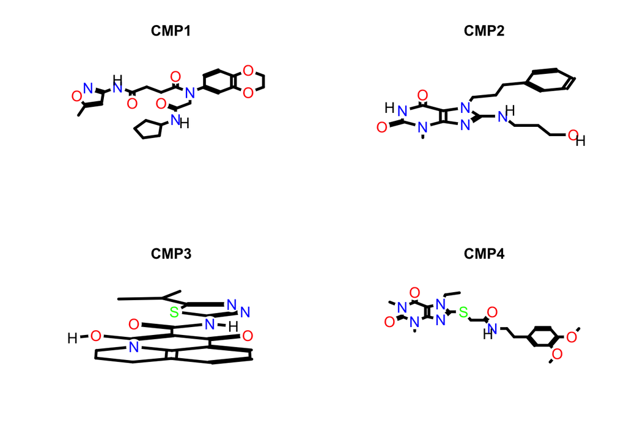

```r
plot(sdfset[1:4], print=FALSE)
```

El sdfset no acepta operaciones del paquete dplyr, por lo que para operar sobre el set de datos este debería cambiarse de formato.  
Se carga otro set de datos en formato csv.

```r
PequeñasMoléculas <- read.delim("INPUT/DATA/SmallMolecules.csv", sep = ";")

summary(PequeñasMoléculas)
```

```
##   ChEMBL.ID             Name             Synonyms             Type
##  Length:58295       Length:58295       Length:58295       Length:58295
##  Class :character   Class :character   Class :character   Class :character
##  Mode  :character   Mode  :character   Mode  :character   Mode  :character
##
##
##
##
##    Max.Phase Molecular.Weight    Targets        Bioactivities
##  Min.   :0   Min.   :350.3    Min.   :  1.000   Min.   :   1.000
##  1st Qu.:0   1st Qu.:510.5    1st Qu.:  1.000   1st Qu.:   1.000
##  Median :0   Median :522.7    Median :  2.000   Median :   3.000
##  Mean   :0   Mean   :521.9    Mean   :  4.617   Mean   :   6.834
##  3rd Qu.:0   3rd Qu.:535.9    3rd Qu.:  4.000   3rd Qu.:   6.000
##  Max.   :0   Max.   :550.0    Max.   :644.000   Max.   :1070.000
##                               NA's   :2566      NA's   :2566
##      AlogP        Polar.Surface.Area      HBA              HBD
##  Min.   :-7.360   Min.   :  0.00     Min.   : 0.000   Min.   : 0.000
##  1st Qu.: 5.260   1st Qu.: 64.63     1st Qu.: 4.000   1st Qu.: 1.000
##  Median : 5.820   Median : 83.09     Median : 6.000   Median : 1.000
##  Mean   : 5.515   Mean   : 90.85     Mean   : 5.981   Mean   : 1.832
##  3rd Qu.: 6.580   3rd Qu.:104.14     3rd Qu.: 7.000   3rd Qu.: 2.000
##  Max.   :13.830   Max.   :336.66     Max.   :17.000   Max.   :12.000
##
##  X.RO5.Violations X.Rotatable.Bonds  Passes.Ro3         QED.Weighted
##  Min.   :2        Min.   : 0.000    Length:58295       Min.   :0.0300
##  1st Qu.:2        1st Qu.: 6.000    Class :character   1st Qu.:0.2200
##  Median :2        Median : 7.000    Mode  :character   Median :0.2800
##  Mean   :2        Mean   : 7.843                       Mean   :0.2875
##  3rd Qu.:2        3rd Qu.: 9.000                       3rd Qu.:0.3500
##  Max.   :2        Max.   :34.000                       Max.   :0.6400
##
##  CX.Acidic.pKa      CX.Basic.pKa         CX.LogP            CX.LogD
##  Length:58295       Length:58295       Length:58295       Length:58295
##  Class :character   Class :character   Class :character   Class :character
##  Mode  :character   Mode  :character   Mode  :character   Mode  :character
##
##
##
##
```

[output cut: 17 more lines]

```
##  Length:58295                    Length:58295       Length:58295
##  Class :character                Class :character   Class :character
##  Mode  :character                Mode  :character   Mode  :character
##
##
##
##
##     Smiles
##  Length:58295
##  Class :character
##  Mode  :character
##
##
##
##
```

Una vez observadas las columnas disponibles, se seleccionan aquellas con las que se va a trabajar, renombrándolas.

Dado que en la columna ChEMBL.ID solo nos interesa el código numérico, se va a eliminar de cada fila las letras mediante el método substring.

```r
DatosMoleculares <- PequeñasMoléculas %>%
  select(ChEMBL.ID, Molecular.Weight, Polar.Surface.Area, CX.Acidic.pKa, CX.Basic.pKa, Aromatic.Rings, Molecular.Species, Molecular.Formula) %>%
  rename(ID = ChEMBL.ID, Peso_Molecular = Molecular.Weight, Superficie = Polar.Surface.Area, pKa_Acido = CX.Acidic.pKa, pKa_Basico = CX.Basic.pKa, Anillos = Aromatic.Rings, Tipo_Molecula = Molecular.Species, Formula_Molecular = Molecular.Formula ) %>%
  mutate(ID = substr(ID, 7, 14))
DatosMoleculares
```

| ID | Peso_Molecular | Superficie | pKa_Acido | pKa_Basico | Anillos | Tipo_Molecula | Formula_Molecular |
| --- | --- | --- | --- | --- | --- | --- | --- |
| 401864 | 534.70 | 67.23 | None | 9.29 | 3 | BASE | C30H35FN4O2S |
| 1197172 | 546.90 | 184.46 | 10.24 | None | 2 | NEUTRAL | C21H28ClN4O9P |
| 1181162 | 515.80 | 73.86 | 13.82 | None | 0 | NEUTRAL | C29H59N2O5+ |
| 1616442 | 531.65 | 78.51 | 7.58 | 8.56 | 3 | BASE | C26H27F2N3O3S2 |
| 2021381 | 402.41 | 171.80 | 12.44 | 6.59 | 3 | NEUTRAL | C18H22N6O5 |
| 170699 | 503.94 | 95.59 | 13.24 | None | 5 | NEUTRAL | C27H22ClN3O5 |
| 312216 | 518.70 | 112.57 | 4.56 | None | 2 | ACID | C26H34N2O5S2 |
| 278972 | 513.63 | 79.60 | None | 8.57 | 3 | BASE | C29H39NO7 |
| 3598297 | 504.99 | 67.23 | 11.39 | 1.10 | 4 | NEUTRAL | C28H26ClFN4O2 |
| 4078692 | 547.47 | 93.54 | 13.76 | 6.61 | 4 | NEUTRAL | C24H24Cl2N6O3S |

[output cut: 9990 more lines]

Con esta tabla se va a trabajar para seleccionar las moléculas que cumplan ciertos criterios.

Se seleccionan las moléculas grandes, que cuenten con varios anillos y que sean neutras en cuanto a cargas atómicas.

```r
Moleculas_Grandes <- DatosMoleculares %>%
  filter(Peso_Molecular >= 530.00, Anillos >= 4, Tipo_Molecula == "NEUTRAL")

Moleculas_Grandes
```

| ID | Peso_Molecular | Superficie | pKa_Acido | pKa_Basico | Anillos | Tipo_Molecula | Formula_Molecular |
| --- | --- | --- | --- | --- | --- | --- | --- |
| 4078692 | 547.47 | 93.54 | 13.76 | 6.61 | 4 | NEUTRAL | C24H24Cl2N6O3S |
| 1581352 | 548.65 | 157.08 | 7.67 | None | 4 | NEUTRAL | C20H16N6O5S4 |
| 4228804 | 536.89 | 79.04 | 11.36 | 6.11 | 4 | NEUTRAL | C25H18ClF5N4O2 |
| 577860 | 530.11 | 55.20 | None | 0.24 | 4 | NEUTRAL | C32H36ClN3O2 |
| 2041401 | 537.58 | 126.91 | None | 2.00 | 5 | NEUTRAL | C29H27N7O4 |
| 2003124 | 536.44 | 63.68 | None | None | 4 | NEUTRAL | C28H19Cl2NO4S |
| 2137394 | 547.54 | 76.11 | None | 1.70 | 5 | NEUTRAL | C29H24F3N5O3 |
| 2408674 | 540.66 | 66.38 | None | None | 4 | NEUTRAL | C34H36O6 |
| 524793 | 548.48 | 74.69 | None | 8.23 | 4 | NEUTRAL | C29H30BrN3O3 |
| 3417439 | 542.08 | 80.32 | None | 7.31 | 4 | NEUTRAL | C32H32ClN3O3 |

[output cut: 6748 more lines]

Se van a agrupar los pesos moleculares para reducir el número de filas y poder trabajar con ellas más fácilmente.

```r
pesoMol_numAnillos0 <- DatosMoleculares %>%
  filter(Anillos == 0) %>%
  mutate(Peso_Promedio = mean(Peso_Molecular, na.rm = TRUE)) %>%
  select(Peso_Promedio, Anillos)

sinAnillos <- distinct(pesoMol_numAnillos0)

sinAnillos
```

| Peso_Promedio | Anillos |
| --- | --- |
| 512.186 | 0 |

```r
pesoMol_numAnillos1 <- DatosMoleculares %>%
  filter(Anillos == 1) %>%
  mutate(Peso_Promedio = mean(Peso_Molecular, na.rm = TRUE)) %>%
  select(Peso_Promedio, Anillos)

unAnillo <- distinct(pesoMol_numAnillos1)

unAnillo
```

| Peso_Promedio | Anillos |
| --- | --- |
| 517.4796 | 1 |

```r
pesoMol_numAnillos2 <- DatosMoleculares %>%
  filter(Anillos == 2) %>%
  mutate(Peso_Promedio = mean(Peso_Molecular, na.rm = TRUE)) %>%
  select(Peso_Promedio, Anillos)

dosAnillos <- distinct(pesoMol_numAnillos2)

dosAnillos
```

| Peso_Promedio | Anillos |
| --- | --- |
| 519.6237 | 2 |

```r
pesoMol_numAnillos3 <- DatosMoleculares %>%
  filter(Anillos == 3) %>%
  mutate(Peso_Promedio = mean(Peso_Molecular, na.rm = TRUE)) %>%
  select(Peso_Promedio, Anillos)

tresAnillos <- distinct(pesoMol_numAnillos3)

tresAnillos
```

| Peso_Promedio | Anillos |
| --- | --- |
| 521.7126 | 3 |

```r
pesoMol_numAnillos4 <- DatosMoleculares %>%
  filter(Anillos == 4) %>%
  mutate(Peso_Promedio = mean(Peso_Molecular, na.rm = TRUE)) %>%
  select(Peso_Promedio, Anillos)

cuatroAnillos <- distinct(pesoMol_numAnillos4)

cuatroAnillos
```

| Peso_Promedio | Anillos |
| --- | --- |
| 523.9699 | 4 |

```r
pesoMol_numAnillos5 <- DatosMoleculares %>%
  filter(Anillos == 5) %>%
  mutate(Peso_Promedio = mean(Peso_Molecular, na.rm = TRUE)) %>%
  select(Peso_Promedio, Anillos)

cincoAnillos <- distinct(pesoMol_numAnillos5)

cincoAnillos
```

| Peso_Promedio | Anillos |
| --- | --- |
| 524.4933 | 5 |

Se crea una tabla que contengan las anteriores y se muestra una gráfica, para evaluar si hay relación entre el número de anillos de una molécula y su peso molecular.

```r
AnillosPeso = data.frame(rbind(sinAnillos, unAnillo, dosAnillos, tresAnillos, cuatroAnillos, cincoAnillos))

AnillosPeso
```

| Peso_Promedio | Anillos |
| --- | --- |
| 512.1860 | 0 |
| 517.4796 | 1 |
| 519.6237 | 2 |
| 521.7126 | 3 |
| 523.9699 | 4 |
| 524.4933 | 5 |

Se representan de forma simple con plot.

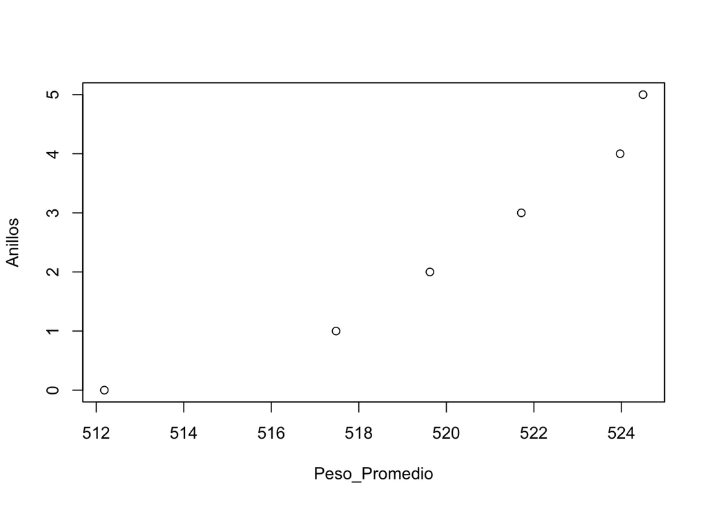

```r
plot(AnillosPeso)
```